# Intro to RStudio Addins & Shiny Gadgets

## Introduction

R is a powerful programming language for statistical computing with many packages and tools.

The goal of this article is to arm you with tools and techniques for using addins and gadgets.

- https://blog.rstudio.org/2016/02/09/new-release-of-rstudio-v0-99-878/
- https://www.rstudio.com/resources/webinars/understanding-add-ins/
- https://www.rstudio.com/resources/webinars/shiny-gadgets-interactive-tools/

We’ll cover two main approaches:

1. **Addins**

   RStudio addins provide a mechanism for executing R functions interactively from within the RStudio IDE—either through keyboard shortcuts, or through the Addins menu.
2. **Gadgets**

   Gadgets are interactive tools that enhance your R programming experience.

## Addins

### addinexamples

- https://rstudio.github.io/rstudioaddins/
- addinexamples

### Example - 1 – `Subset a Dataframe`

### Example - 2 – `Find and Replace`

## Gadgets

### Info

- https://shiny.rstudio.com/articles/gadgets.html
- http://shiny.rstudio.com/articles/gadget-ui.html

### NYC R Confernece

- https://github.com/nwstephens/nyr2016

### Example - 1 – `selectConn.R`

### Example - 2 – `variableProfiler.R`

### rstudio/sol-eng-public

- https://github.com/rstudio/sol-eng-public/tree/master/newTopics/04-Gadgets

### Example - 1 – `lmGadget.R`

### Example - 2 – `pick_points.R`

### Example - 1 – `diamonds ggplot2`

- https://github.com/calligross/ggthemeassist
- https://github.com/philbowsher/Chicago-R-Meetup-Shiny-Aug-2016

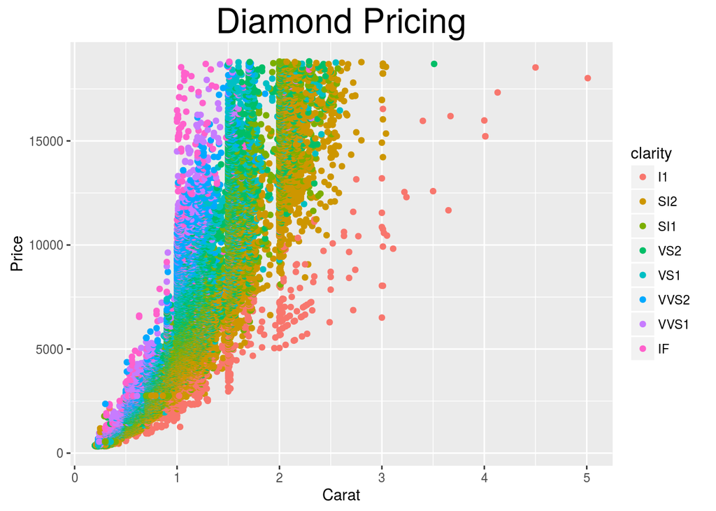

```r
library(ggplot2)

#summary(diamonds)

#summary(diamonds$price)

aveSize <- round(mean(diamonds$carat), 4)
clarity <- levels(diamonds$clarity)

p <- qplot(carat, price, data = diamonds, color = clarity) + labs(x = "Carat", y = "Price") + labs(title = "Diamond Pricing")

p + theme(plot.title = element_text(size = 24))
```

### Example - 1 – `fidlr & dygraphs`

- https://beta.rstudioconnect.com/content/1917/#
- http://www.thertrader.com/2016/04/21/introducing-fidlr-financial-data-loader/
- https://github.com/thertrader/fidlr

```r
library(dygraphs)
```

```r
##let's load up some economic data the old-fashioned way
library(quantmod)
getSymbols(Symbols = "GDP",
                     src = "FRED",
                     env = globalenv())
```

```r
##let's use an add-in to load up some economic data
##first, install the package
devtools::install_github("thertrader/fidlr")

##now click on Addins at the top of the IDE, select fidlr
##in the source drop down, click on Fred
##in the instrument panel, type GDP
##click Run, then click Close
##in the Environment panel, there should be an xts object called GDP
##now run this code chunk by clicking on the green triangle at line 20

##use the US econ data
    dygraph(GDP) %>%
    dyRangeSelector(height = 20) %>%
    dyShading(from = "2001-03-01", to = "2001-11-01", color = "#FFE6E6") %>%
    dyShading(from = "2007-12-01", to = "2009-06-01", color = "#FFE6E6") %>%
    dyEvent(x = "2008-09-15", label = "Lehman Fails", labelLoc = "top", color = "red") %>%
    dyEvent(x = "1987-09-15", label = "Black Monday", labelLoc = "top", color = "black") %>%
    dyEvent(x = "1982-12-01", label = "Volcker Eases", labelLoc = "top", color = "green")
```

```r
##use the add in to get some currency data
##open the addin
##select the data source Oanda
##type in GBP/EUR to pull in data on the British pound / Euro
##click Run, click Close
##now there's a data object called GBPEUR in the environment

##now let's use it in a dygraph
      dygraph(GBPEUR) %>%
      dyRangeSelector(height = 20) %>%
      dyAxis("y", label = "GBP/EUR", axisLabelFontSize = 10, axisLabelWidth = 70) %>%
      dyEvent(x = "2016-06-23", label = "Brexit", labelLoc = "top", color = "blue")
```

## How do I share a package (since an addin is just a package) I’ve created within my organization?

- https://support.rstudio.com/hc/en-us/articles/115000239587-Sharing-Internal-R-Packages
- Note: Pre-req is you have a package … there are a few resources online that show how to use RStudio to create an R package
- https://support.rstudio.com/hc/en-us/articles/200486488-Developing-Packages-with-RStudio
- Option A: Share File
- You will want to build the package into a source / tar file. This is done in the IDE with “Build Source Package” within the Build tab.
- You can then put that tar file in a shared network location. Users can download the tar file and then install it with:

```r
 install.packages("path/to/tar/file", source = TRUE)
```

- Option B: Use Git
- You can put the whole R package (the R folder, namespace file, description, etc) into a git repo (either an internal repo or github). Then users can get the package using devtools

```r
 devtools::install_git(repo_url)
```

- Option C: Use Local Repo
- These instructions: https://rstudio.github.io/packrat/custom-repos.html will provide a framework for setting up a local repo and adding packages to it. In particular:
- 1. Update the package’s DESCRIPTION file to have a home repo and build it (A.1).
- 2. Move the tar file into the correct location for your local repo.
- 3. Update the repo’s PACKAGE files using tools::write_PACKAGES

Then users can install the package with

```r
install.packages('package_name', source = TRUE)
```

- Option D: System Library
- If you are using RSP, you can make your addin automatically available to users by installing the package in the system library. To do so, just use one of the methods above (A-C) and install the package into the system location:

```r
install.packages('my_package', source=TRUE, lib.loc = "/path/to/system/lib")
```

## Interesting

### Info

- https://datasciencespecialization.github.io/Developing_Data_Products/Shiny_Gadgets/Shiny_Gadgets.html#1
- https://rpubs.com/seandavi/bioc2016_gadgets

### addinslist package

- https://github.com/daattali/addinslist
- http://deanattali.com/blog/addinslist-package/

### Sparklyr

- https://rpubs.com/nwstephens/nyc-taxi-demo

### Interesting Addins

- https://www.r-bloggers.com/a-gadget-for-tidyr/
- http://data-laborer.eu/2016/04/ARIMA_Picker.html
- https://github.com/bnosac/taskscheduleR
- http://zachcp.org/blog/2016/sketcher_gadget/
- https://stevenmortimer.com/2016/12/10/creating-an-rstudio-addin/
- http://deanattali.com/blog/plot-colour-helper/

### Joe Cheng’s talk at EARL which included addins

- https://www.youtube.com/watch?v=MrQVzz2POD4

### Mango’s Presentation on addins

- http://www.rmanchester.org/presentations/2016/02/ManchesterR_-_Developing_Analysis_Tools_with_Shiny_Gadgets_-_Aimee_Gott_-_20160229.pdf